# Praktikum 2_Laihan 1_Pemulusan

Abdullah Zeith Alfarizy (G1401231060)

2025-09-01

```r
library("forecast")
```

```r
library("graphics")
library("TTR")
library("TSA")
```

## Impor Data

```r
# data fmcg 1-100
library(rio)
data0 <- import("https://raw.githubusercontent.com/nyayunabila/mpdw/refs/heads/main/Pertemuan%201/data-kelompok-9-mpdw.csv")
data0
```

```
##           date daily_revenue
## 1    8/19/2023        334.32
## 2    8/20/2023        140.92
## 3    8/21/2023        296.88
## 4    8/22/2023        157.86
## 5    8/23/2023        211.18
## 6    8/24/2023         76.58
## 7    8/25/2023         44.00
## 8    8/26/2023        221.09
## 9    8/27/2023        511.40
## 10   8/28/2023        151.50
## 11   8/29/2023         94.35
## 12   8/30/2023        158.52
## 13   8/31/2023        133.35
## 14    9/1/2023        128.49
```

[output cut: 486 more lines]

```r
data_z <- data0[1:100, ]
data_z
```

```
##           date daily_revenue
## 1    8/19/2023        334.32
## 2    8/20/2023        140.92
## 3    8/21/2023        296.88
## 4    8/22/2023        157.86
## 5    8/23/2023        211.18
## 6    8/24/2023         76.58
## 7    8/25/2023         44.00
## 8    8/26/2023        221.09
## 9    8/27/2023        511.40
## 10   8/28/2023        151.50
## 11   8/29/2023         94.35
## 12   8/30/2023        158.52
## 13   8/31/2023        133.35
## 14    9/1/2023        128.49
```

[output cut: 86 more lines]

# Eksplorasi Data

```r
str(data_z)
```

```
## 'data.frame':    100 obs. of  2 variables:
##  $ date         : chr  "8/19/2023" "8/20/2023" "8/21/2023" "8/22/2023" ...
##  $ daily_revenue: num  334 141 297 158 211 ...
```

```r
dim(data_z)
```

```
## [1] 100   2
```

```r
# Mengubah kolom date yang bertipe character menjadi Date
data_z$date <- as.Date(data_z$date, format="%m/%d/%Y")
```

```r
str(data_z)
```

```
## 'data.frame':    100 obs. of  2 variables:
##  $ date         : Date, format: "2023-08-19" "2023-08-20" ...
##  $ daily_revenue: num  334 141 297 158 211 ...
```

```r
data_z
```

```
##           date daily_revenue
## 1   2023-08-19        334.32
## 2   2023-08-20        140.92
## 3   2023-08-21        296.88
## 4   2023-08-22        157.86
## 5   2023-08-23        211.18
## 6   2023-08-24         76.58
## 7   2023-08-25         44.00
## 8   2023-08-26        221.09
## 9   2023-08-27        511.40
## 10  2023-08-28        151.50
## 11  2023-08-29         94.35
## 12  2023-08-30        158.52
## 13  2023-08-31        133.35
## 14  2023-09-01        128.49
```

[output cut: 86 more lines]

```r
data_z.ts <- ts(data_z$daily_revenue)
```

```r
summary(data_z.ts)
```

```
##    Min. 1st Qu.  Median    Mean 3rd Qu.    Max.
##   23.52  100.83  155.55  176.36  232.82  511.40
```

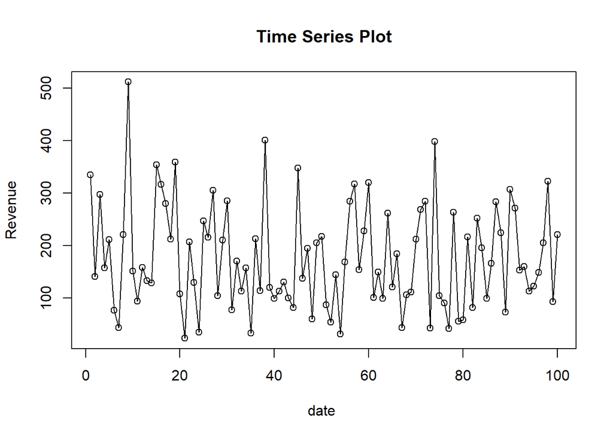

```r
ts.plot(data_z.ts, xlab="date ", ylab="Revenue",
        main = "Time Series Plot")
points(data_z.ts)
```

### Pembagian Data

```r
#membagi training dan testing
training<-data_z[1:80,]
testing<-data_z[81:100,]
train.ts <- ts(training$daily_revenue)
test.ts <- ts(testing$daily_revenue)
```

### Eksplorasi Data

Eksplorasi data dilakukan pada keseluruhan data, data latih serta data uji menggunakan plot data deret waktu.

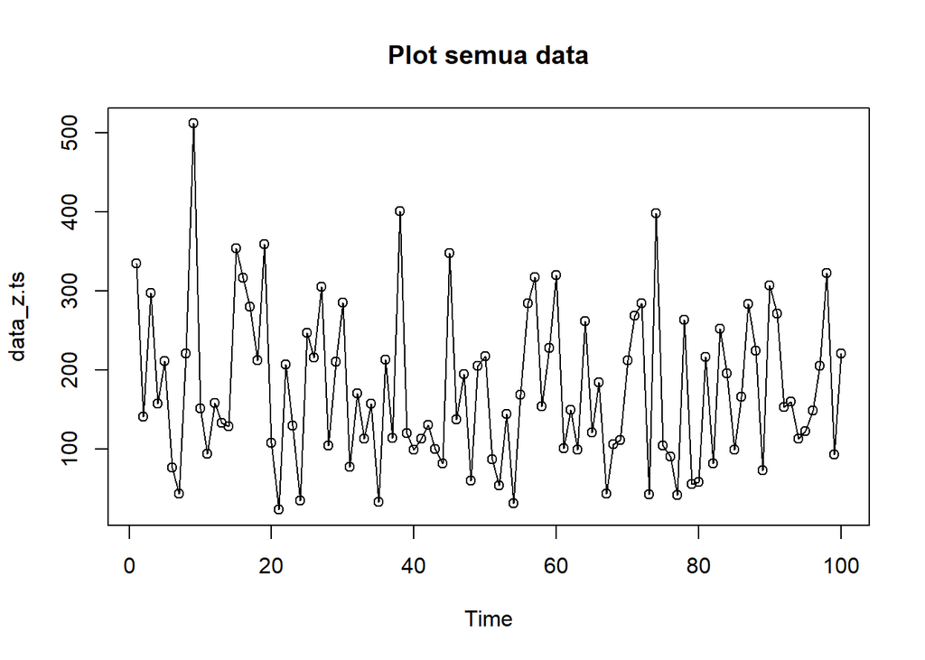

```r
#eksplorasi data
plot(data_z.ts, col="black",main="Plot semua data")
points(data_z.ts)
```

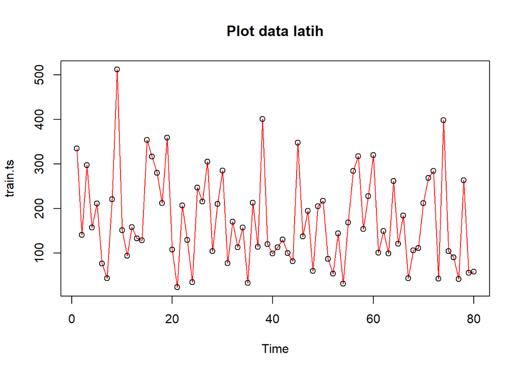

```r
plot(train.ts, col="red",main="Plot data latih")
points(train.ts)
```

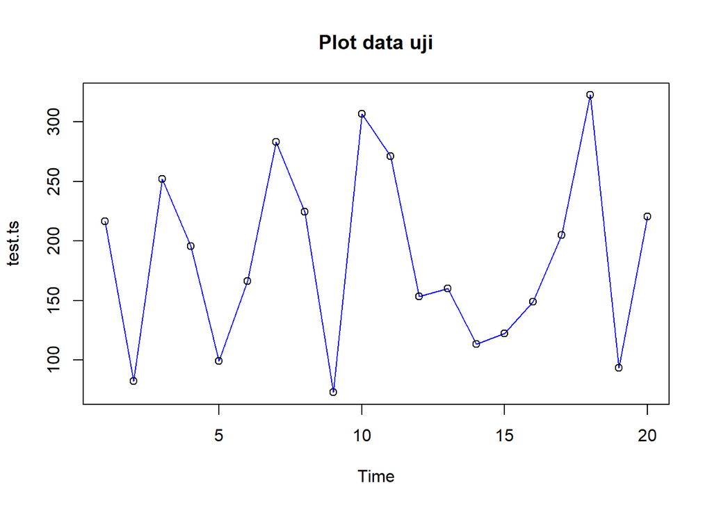

```r
plot(test.ts, col="blue",main="Plot data uji")
points(test.ts)
```

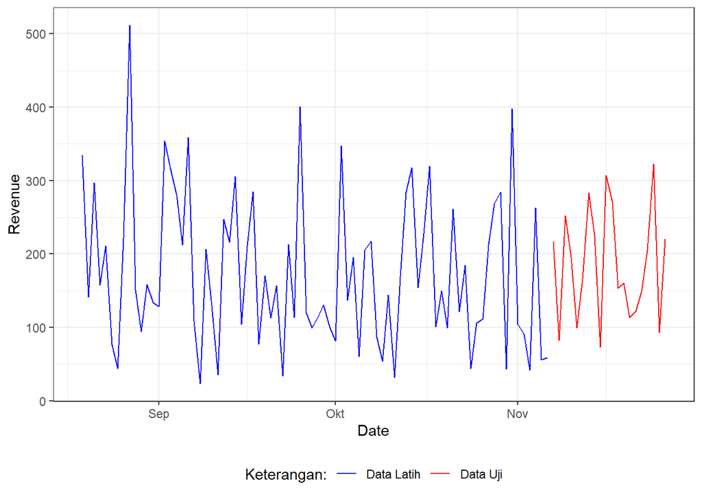

```r
#Eksplorasi dengan GGPLOT
library(ggplot2)
ggplot() +
  geom_line(data = training, aes(x = date, y = daily_revenue, col = "Data Latih")) +
  geom_line(data = testing, aes(x = date, y = daily_revenue, col = "Data Uji")) +
  labs(x = "Date", y = "Revenue", color = "Legend") +
  scale_colour_manual(name="Keterangan:", breaks = c("Data Latih", "Data Uji"),
                      values = c("blue", "red")) +
  theme_bw() + theme(legend.position = "bottom",
                     plot.caption = element_text(hjust=0.5, size=12))
```

# Single Moving Average & Double Moving Average Dalam eksplorasi plot time series sebelumnya terlihat bahwa pola data dapat diasumsikan memiliki pola yang konstan sehingga pertama akan dilakukan pemulusan dengan metode single moving average. ## SMA

```r
data.sma<-SMA(train.ts, n=3)
data.sma
```

```
## Time Series:
## Start = 1
## End = 80
## Frequency = 1
##  [1]        NA        NA 257.37333 198.55333 221.97333 148.54000 110.58667
##  [8] 113.89000 258.83000 294.66333 252.41667 134.79000 128.74000 140.12000
## [15] 205.23000 266.11333 316.54333 269.30333 283.54333 226.36333 163.49333
## [22] 112.88333 119.98333 123.82333 137.25333 166.05333 256.18000 208.53333
## [29] 206.81000 199.97000 191.01333 177.52000 120.16333 146.76333 101.20000
## [36] 134.55000 120.05000 242.33000 211.27000 206.52667 110.79333 114.31333
## [43] 114.56667 104.10000 176.43667 188.72667 226.46667 130.68333 153.48333
## [50] 160.96000 169.91667 119.32667  94.85667  76.54667 114.99333 161.59000
## [57] 256.73000 251.69333 233.08000 233.89333 216.26333 190.26333 116.87000
## [64] 170.36667 160.80667 189.16000 116.65000 111.53333  87.16667 143.30000
## [71] 197.37000 254.97333 198.51000 241.76333 181.79333 197.67667  78.95333
## [78] 131.87333 120.34000 125.95333
```

```r
data.ramal<-c(NA,data.sma)
data.ramal #forecast 1 periode ke depan
```

```
##  [1]        NA        NA        NA 257.37333 198.55333 221.97333 148.54000
##  [8] 110.58667 113.89000 258.83000 294.66333 252.41667 134.79000 128.74000
## [15] 140.12000 205.23000 266.11333 316.54333 269.30333 283.54333 226.36333
## [22] 163.49333 112.88333 119.98333 123.82333 137.25333 166.05333 256.18000
## [29] 208.53333 206.81000 199.97000 191.01333 177.52000 120.16333 146.76333
## [36] 101.20000 134.55000 120.05000 242.33000 211.27000 206.52667 110.79333
## [43] 114.31333 114.56667 104.10000 176.43667 188.72667 226.46667 130.68333
## [50] 153.48333 160.96000 169.91667 119.32667  94.85667  76.54667 114.99333
## [57] 161.59000 256.73000 251.69333 233.08000 233.89333 216.26333 190.26333
## [64] 116.87000 170.36667 160.80667 189.16000 116.65000 111.53333  87.16667
## [71] 143.30000 197.37000 254.97333 198.51000 241.76333 181.79333 197.67667
## [78]  78.95333 131.87333 120.34000 125.95333
```

```r
data.gab<-cbind(aktual=c(train.ts,rep(NA,24)),pemulusan=c(data.sma,rep(NA,24)),ramalan=c(data.ramal,rep(data.ramal[length(data.ramal)],23)))
data.gab #forecast 24 periode ke depan
```

```
##        aktual pemulusan   ramalan
##   [1,] 334.32        NA        NA
##   [2,] 140.92        NA        NA
##   [3,] 296.88 257.37333        NA
##   [4,] 157.86 198.55333 257.37333
##   [5,] 211.18 221.97333 198.55333
##   [6,]  76.58 148.54000 221.97333
##   [7,]  44.00 110.58667 148.54000
##   [8,] 221.09 113.89000 110.58667
##   [9,] 511.40 258.83000 113.89000
##  [10,] 151.50 294.66333 258.83000
##  [11,]  94.35 252.41667 294.66333
##  [12,] 158.52 134.79000 252.41667
##  [13,] 133.35 128.74000 134.79000
##  [14,] 128.49 140.12000 128.74000
```

[output cut: 90 more lines]

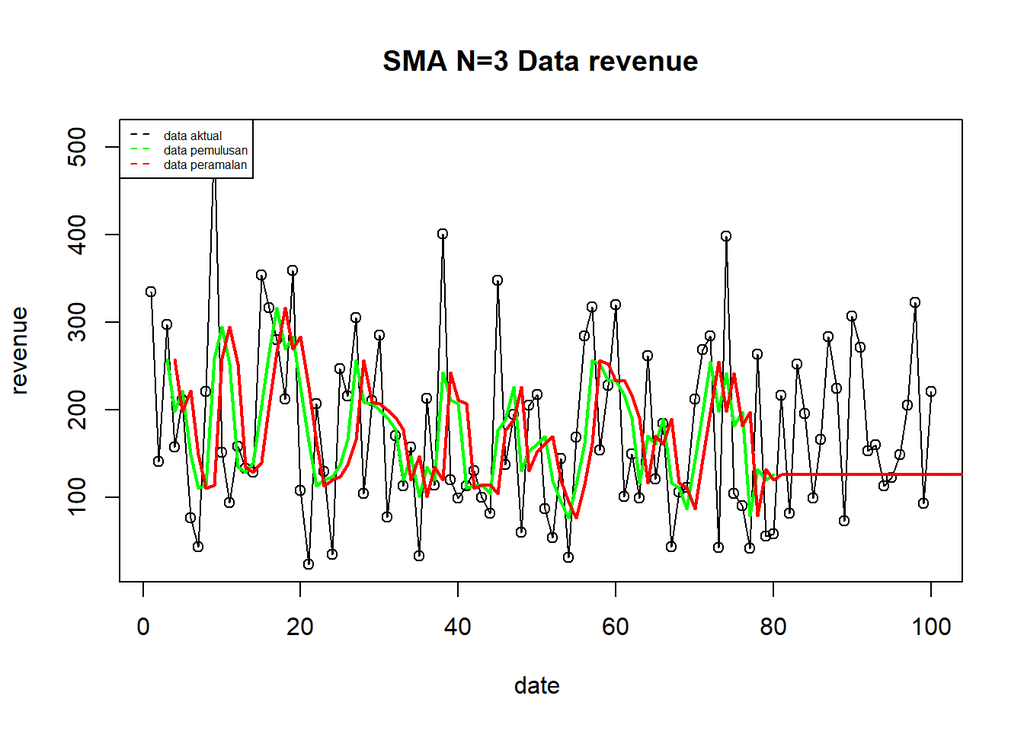

```r
ts.plot(data_z.ts, xlab="date ", ylab="revenue", main= "SMA N=3 Data revenue")
points(data_z.ts)
lines(data.gab[,2],col="green",lwd=2)
lines(data.gab[,3],col="red",lwd=2)
legend("topleft",c("data aktual","data pemulusan","data peramalan"), lty=8, col=c("black","green","red"), cex=0.5)
```

```r
#Menghitung nilai keakuratan data latih
error_train.sma = train.ts-data.ramal[1:length(train.ts)]
SSE_train.sma = sum(error_train.sma[4:length(train.ts)]^2)
MSE_train.sma = mean(error_train.sma[4:length(train.ts)]^2)
MAPE_train.sma = mean(abs((error_train.sma[4:length(train.ts)]/train.ts[4:length(train.ts)])*100))

akurasi_train.sma <- matrix(c(SSE_train.sma, MSE_train.sma, MAPE_train.sma))
row.names(akurasi_train.sma)<- c("SSE", "MSE", "MAPE")
colnames(akurasi_train.sma) <- c("Akurasi m = 3")
akurasi_train.sma
```

```
##      Akurasi m = 3
## SSE   1.159919e+06
## MSE   1.506389e+04
## MAPE  9.590383e+01
```

Dalam hal ini nilai MAPE data latih pada metode pemulusan SMAn didapatkan sebesar 96%, nilai ini dapat dikategorikan sebagai nilai akurasi yang kurang baik karena sudah jauh di atas 10%. Selanjutnya dilakukan perhitungan nilai MAPE data uji pada metde pemulusan SMA.

```r
#Menghitung nilai keakuratan data uji
error_test.sma = test.ts-data.gab[81:100,3]
SSE_test.sma = sum(error_test.sma^2)
MSE_test.sma = mean(error_test.sma^2)
MAPE_test.sma = mean(abs((error_test.sma/test.ts*100)))

akurasi_test.sma <- matrix(c(SSE_test.sma, MSE_test.sma, MAPE_test.sma))
row.names(akurasi_test.sma)<- c("SSE", "MSE", "MAPE")
colnames(akurasi_test.sma) <- c("Akurasi m = 3")
akurasi_test.sma
```

```
##      Akurasi m = 3
## SSE   181743.24712
## MSE     9087.16236
## MAPE      38.13535
```

Perhitungan akurasi menggunakan data latih juga menghasilkan nilai MAPE yang jauh di atas 10% sehingga nilai akurasi ini dapat dikategorikan kurang baik.

Selnjutnya dilakukan metode - metode pemulusan lain untuk memeriksa apakah ada yang memeberikan akurasi yang baik ## DMA

```r
dma <- SMA(data.sma, n = 3)
At <- 2*data.sma - dma
Bt <- 2/(3-1)*(data.sma - dma)
data.dma<- At+Bt
data.ramal2<- c(NA, data.dma)

t = 1:24
f = c()

for (i in t) {
  f[i] = At[length(At)] + Bt[length(Bt)]*(i)
}

data.gab2 <- cbind(aktual = c(train.ts,rep(NA,24)), pemulusan1 = c(data.sma,rep(NA,24)),pemulusan2 = c(data.dma, rep(NA,24)),At = c(At, rep(NA,24)), Bt = c(Bt,rep(NA,24)),ramalan = c(data.ramal2, f[-1]))
data.gab2
```

```
##        aktual pemulusan1 pemulusan2         At          Bt    ramalan
##   [1,] 334.32         NA         NA         NA          NA         NA
##   [2,] 140.92         NA         NA         NA          NA         NA
##   [3,] 296.88  257.37333         NA         NA          NA         NA
##   [4,] 157.86  198.55333         NA         NA          NA         NA
##   [5,] 211.18  221.97333 213.986667 217.980000  -3.9933333         NA
##   [6,]  76.58  148.54000  66.242222 107.391111 -41.1488889 213.986667
##   [7,]  44.00  110.58667  11.026667  60.806667 -49.7800000  66.242222
##   [8,] 221.09  113.89000  92.992222 103.441111 -10.4488889  11.026667
##   [9,] 511.40  258.83000 454.285556 356.557778  97.7277778  92.992222
##  [10,] 151.50  294.66333 439.067778 366.865556  72.2022222 454.285556
##  [11,]  94.35  252.41667 219.976667 236.196667 -16.2200000 439.067778
##  [12,] 158.52  134.79000 -50.210000  42.290000 -92.5000000 219.976667
##  [13,] 133.35  128.74000  42.255556  85.497778 -43.2422222 -50.210000
##  [14,] 128.49  140.12000 151.260000 145.690000   5.5700000  42.255556
```

[output cut: 90 more lines]

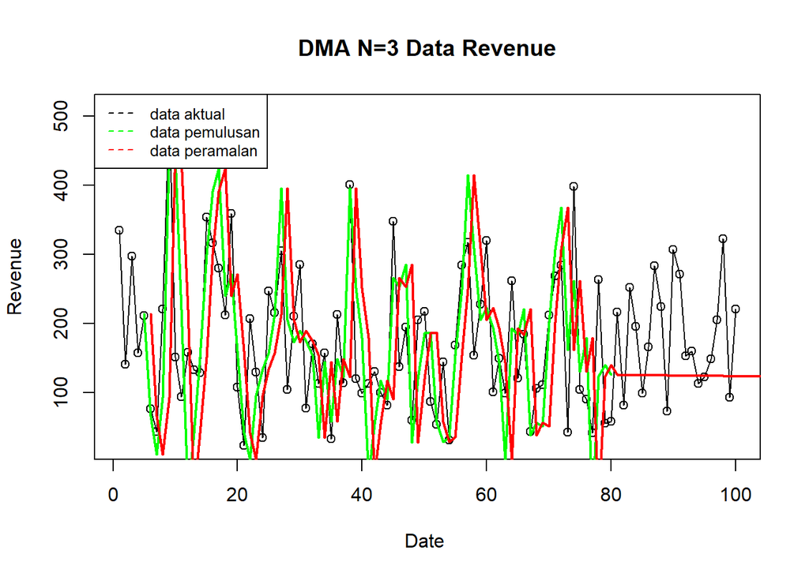

```r
ts.plot(data_z.ts, xlab="Date ", ylab="Revenue", main= "DMA N=3 Data Revenue")
points(data_z.ts)
lines(data.gab2[,3],col="green",lwd=2)
lines(data.gab2[,6],col="red",lwd=2)
legend("topleft",c("data aktual","data pemulusan","data peramalan"), lty=8, col=c("black","green","red"), cex=0.8)
```

```r
#Menghitung nilai keakuratan data latih
error_train.dma = train.ts-data.ramal2[1:length(train.ts)]
SSE_train.dma = sum(error_train.dma[6:length(train.ts)]^2)
MSE_train.dma = mean(error_train.dma[6:length(train.ts)]^2)
MAPE_train.dma = mean(abs((error_train.dma[6:length(train.ts)]/train.ts[6:length(train.ts)])*100))

akurasi_train.dma <- matrix(c(SSE_train.dma, MSE_train.dma, MAPE_train.dma))
row.names(akurasi_train.dma)<- c("SSE", "MSE", "MAPE")
colnames(akurasi_train.dma) <- c("Akurasi m = 3")
akurasi_train.dma
```

```
##      Akurasi m = 3
## SSE   1922244.6738
## MSE     25629.9290
## MAPE      114.4611
```

Perhitungan akurasi pada data latih menggunakan nilai MAPE menghasilkan nilai MAPE yang lebih dari 10% sehingga dikategorikan kurang baik. Selanjutnya, perhitungan nilai akurasi dilakukan pada data uji.

```r
#Menghitung nilai keakuratan data uji
error_test.dma = test.ts-data.gab2[81:100,6]
SSE_test.dma = sum(error_test.dma^2)
MSE_test.dma = mean(error_test.dma^2)
MAPE_test.dma = mean(abs((error_test.dma/test.ts*100)))

akurasi_test.dma <- matrix(c(SSE_test.dma, MSE_test.dma, MAPE_test.dma))
row.names(akurasi_test.dma)<- c("SSE", "MSE", "MAPE")
colnames(akurasi_test.dma) <- c("Akurasi m = 3")
akurasi_test.dma
```

```
##      Akurasi m = 3
## SSE   184607.72050
## MSE     9230.38603
## MAPE      38.16487
```

Perhitungan akurasi menggunakan data latih menghasilkan nilai MAPE yang lebih dari 10% sehingga nilai akurasi ini dapat dikategorikan sebagai akurasi yang kurang baik dalam peramalan

Pada uji keakuratan baik pada data latih maupun pada data uji, metode SMA lebih baik dibandingkan DMA.

# Single Exponential Smoothing & Double Exponential Smoothing

```r
# data fmcg 1-100 (MASIH DATA YANG SAMA SEPERTI DI SMA DAN DMA)
library(rio)
data00 <- import("https://raw.githubusercontent.com/nyayunabila/mpdw/refs/heads/main/Pertemuan%201/data-kelompok-9-mpdw.csv")
```

```r
data_zz <- data0[1:100, ]
```

```r
data_zz$date <- as.Date(data_z$date, format="%m/%d/%Y")
```

```r
training<-data_zz[1:80,]
testing<-data_zz[81:100,]
train_ses.ts <- ts(training$daily_revenue)
test_ses.ts <- ts(testing$daily_revenue)
```

## SES

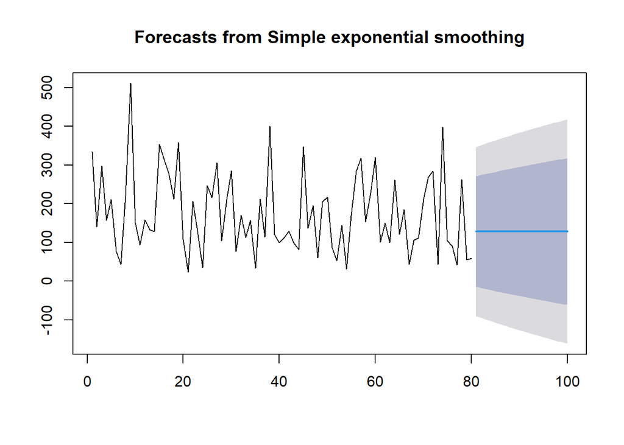

```r
#Cara 1 (fungsi ses)
ses.1 <- ses(train_ses.ts, h = 20, alpha = 0.2)
plot(ses.1)
```

```r
ses.1
```

```
##     Point Forecast     Lo 80    Hi 80      Lo 95    Hi 95
##  81       128.4918 -14.45316 271.4367  -90.12363 347.1071
##  82       128.4918 -17.28403 274.2675  -94.45306 351.4366
##  83       128.4918 -20.06096 277.0445  -98.70001 355.6835
##  84       128.4918 -22.78692 279.7704 -102.86902 359.8525
##  85       128.4918 -25.46463 282.4481 -106.96422 363.9477
##  86       128.4918 -28.09655 285.0801 -110.98940 367.9729
##  87       128.4918 -30.68497 287.6685 -114.94803 371.9315
##  88       128.4918 -33.23196 290.2155 -118.84331 375.8268
##  89       128.4918 -35.73945 292.7230 -122.67820 379.6617
##  90       128.4918 -38.20923 295.1927 -126.45540 383.4389
##  91       128.4918 -40.64295 297.6265 -130.17745 387.1610
##  92       128.4918 -43.04214 300.0256 -133.84670 390.8302
##  93       128.4918 -45.40824 302.3917 -137.46533 394.4488
##  94       128.4918 -47.74257 304.7261 -141.03539 398.0189
##  95       128.4918 -50.04639 307.0299 -144.55877 401.5423
##  96       128.4918 -52.32085 309.3044 -148.03726 405.0208
##  97       128.4918 -54.56706 311.5506 -151.47253 408.4560
##  98       128.4918 -56.78603 313.7695 -154.86616 411.8497
##  99       128.4918 -58.97874 315.9622 -158.21963 415.2031
## 100       128.4918 -61.14610 318.1296 -161.53432 418.5178
```

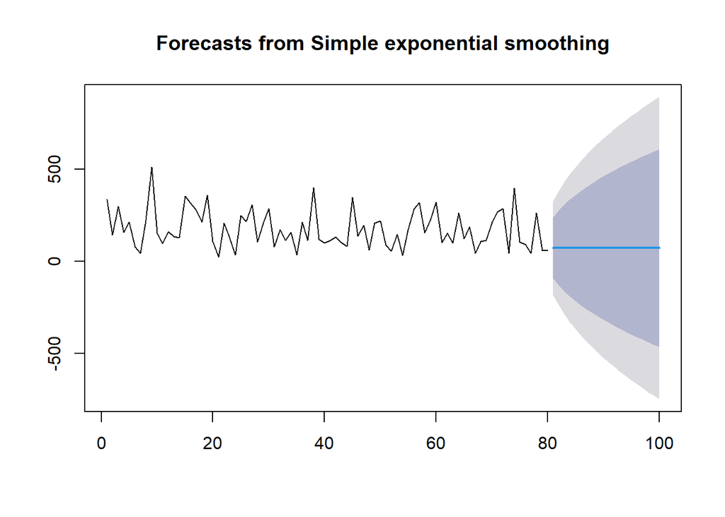

```r
ses.2<- ses(train_ses.ts, h = 20, alpha = 0.7)
plot(ses.2)
```

```r
ses.2
```

```
##     Point Forecast      Lo 80    Hi 80     Lo 95    Hi 95
##  81       71.10882  -96.17689 238.3945 -184.7326 326.9502
##  82       71.10882 -133.08942 275.3070 -241.1854 383.4031
##  83       71.10882 -164.28304 306.5007 -288.8920 431.1096
##  84       71.10882 -191.80131 334.0189 -330.9775 473.1952
##  85       71.10882 -216.70040 358.9180 -369.0574 511.2750
##  86       71.10882 -239.61060 381.8282 -404.0955 546.3132
##  87       71.10882 -260.94384 403.1615 -436.7219 578.9395
##  88       71.10882 -280.98687 423.2045 -467.3751 609.5927
##  89       71.10882 -299.94884 442.1665 -496.3749 638.5925
##  90       71.10882 -317.98782 460.2055 -523.9631 666.1808
##  91       71.10882 -335.22676 477.4444 -550.3278 692.5455
##  92       71.10882 -351.76352 493.9812 -575.6186 717.8362
##  93       71.10882 -367.67749 509.8951 -599.9569 742.1746
##  94       71.10882 -383.03414 525.2518 -623.4429 765.6605
##  95       71.10882 -397.88824 540.1059 -646.1603 788.3779
##  96       71.10882 -412.28610 554.5037 -668.1799 810.3975
##  97       71.10882 -426.26736 568.4850 -689.5624 831.7800
##  98       71.10882 -439.86620 582.0838 -710.3600 852.5777
##  99       71.10882 -453.11239 595.3300 -730.6183 872.8360
## 100       71.10882 -466.03203 608.2497 -750.3772 892.5948
```

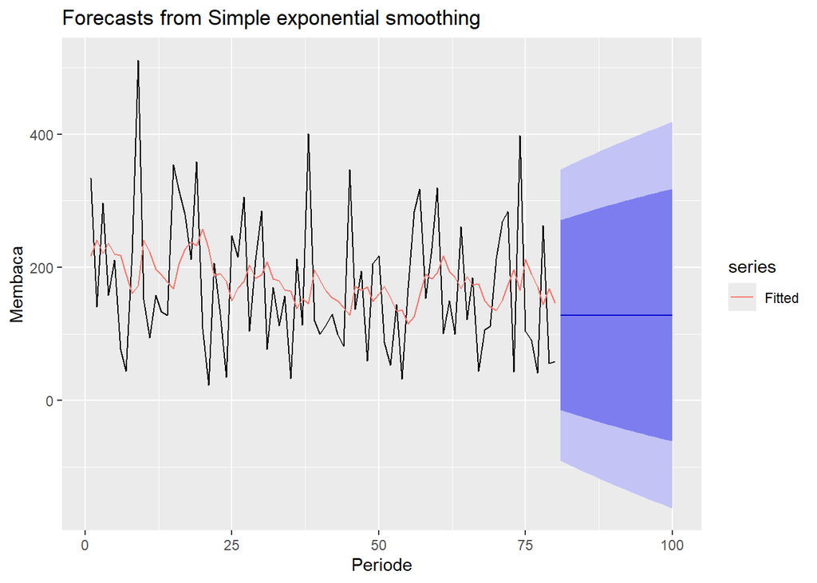

```r
autoplot(ses.1) +
  autolayer(fitted(ses.1), series="Fitted") +
  ylab("Membaca") + xlab("Periode")
```

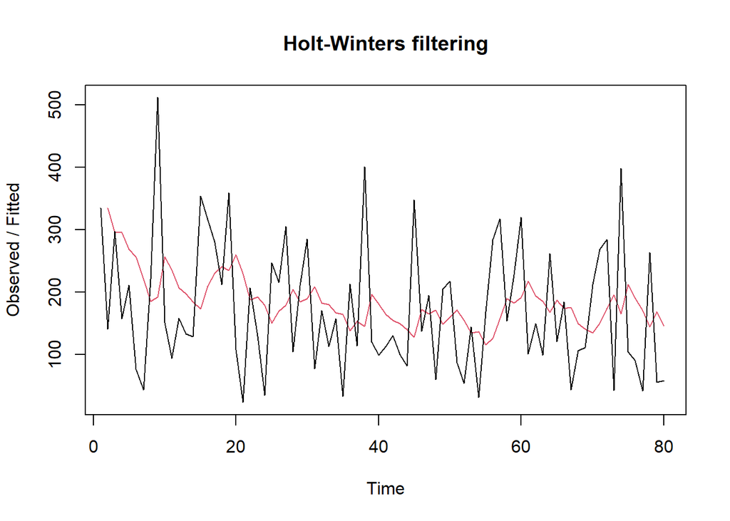

```r
#Cara 2 (fungsi Holtwinter)
ses1<- HoltWinters(train_ses.ts, gamma = FALSE, beta = FALSE, alpha = 0.2)
plot(ses1)
```

```r
#ramalan
ramalan1<- forecast(ses1, h=20)
ramalan1
```

```
##     Point Forecast     Lo 80    Hi 80      Lo 95    Hi 95
##  81       128.4918 -16.23211 273.2156  -92.84430 349.8278
##  82       128.4918 -19.09821 276.0817  -97.22762 354.2111
##  83       128.4918 -21.90970 278.8932 -101.52742 358.5109
##  84       128.4918 -24.66959 281.6531 -105.74831 362.7318
##  85       128.4918 -27.38062 284.3641 -109.89447 366.8780
##  86       128.4918 -30.04530 287.0288 -113.96975 370.9533
##  87       128.4918 -32.66592 289.6494 -117.97764 374.9612
##  88       128.4918 -35.24461 292.2281 -121.92141 378.9049
##  89       128.4918 -37.78331 294.7668 -125.80401 382.7875
##  90       128.4918 -40.28383 297.2673 -129.62822 386.6117
##  91       128.4918 -42.74783 299.7313 -133.39660 390.3801
##  92       128.4918 -45.17689 302.1604 -137.11151 394.0950
##  93       128.4918 -47.57243 304.5559 -140.77518 397.7587
##  94       128.4918 -49.93581 306.9193 -144.38966 401.3732
##  95       128.4918 -52.26830 309.2518 -147.95689 404.9404
##  96       128.4918 -54.57107 311.5546 -151.47867 408.4622
##  97       128.4918 -56.84523 313.8287 -154.95670 411.9402
##  98       128.4918 -59.09182 316.0753 -158.39256 415.3761
##  99       128.4918 -61.31182 318.2953 -161.78776 418.7713
## 100       128.4918 -63.50615 320.4897 -165.14370 422.1272
```

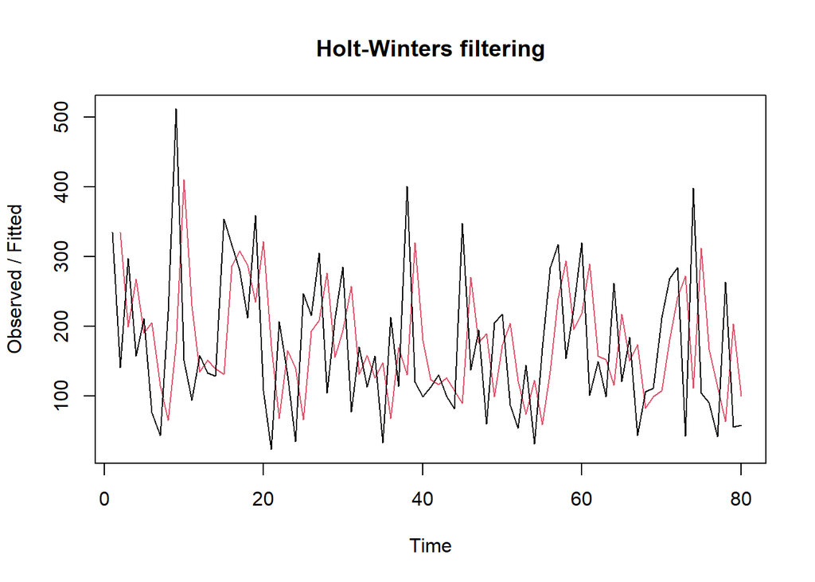

```r
ses2<- HoltWinters(train_ses.ts, gamma = FALSE, beta = FALSE, alpha = 0.7)
plot(ses2)
```

```r
#ramalan
ramalan2<- forecast(ses2, h=20)
ramalan2
```

```
##     Point Forecast      Lo 80    Hi 80     Lo 95    Hi 95
##  81       71.10882  -96.22099 238.4386 -184.8000 327.0177
##  82       71.10882 -133.14324 275.3609 -241.2677 383.4854
##  83       71.10882 -164.34509 306.5627 -288.9869 431.2045
##  84       71.10882 -191.87061 334.0882 -331.0835 473.3011
##  85       71.10882 -216.77626 358.9939 -369.1734 511.3911
##  86       71.10882 -239.69250 381.9101 -404.2208 546.4384
##  87       71.10882 -261.03136 403.2490 -436.8557 579.0734
##  88       71.10882 -281.07968 423.2973 -467.5170 609.7346
##  89       71.10882 -300.04664 442.2643 -496.5245 638.7421
##  90       71.10882 -318.09038 460.3080 -524.1200 666.3376
##  91       71.10882 -335.33386 477.5515 -550.4916 692.7093
##  92       71.10882 -351.87498 494.0926 -575.7891 718.0067
##  93       71.10882 -367.79314 510.0108 -600.1338 742.3514
##  94       71.10882 -383.15385 525.3715 -623.6260 765.8436
##  95       71.10882 -398.01186 540.2295 -646.3493 788.5670
##  96       71.10882 -412.41352 554.6311 -668.3748 810.5924
##  97       71.10882 -426.39845 568.6161 -689.7629 831.9805
##  98       71.10882 -440.00088 582.2185 -710.5660 852.7836
##  99       71.10882 -453.25057 595.4682 -730.8297 873.0473
## 100       71.10882 -466.17360 608.3912 -750.5937 892.8114
```

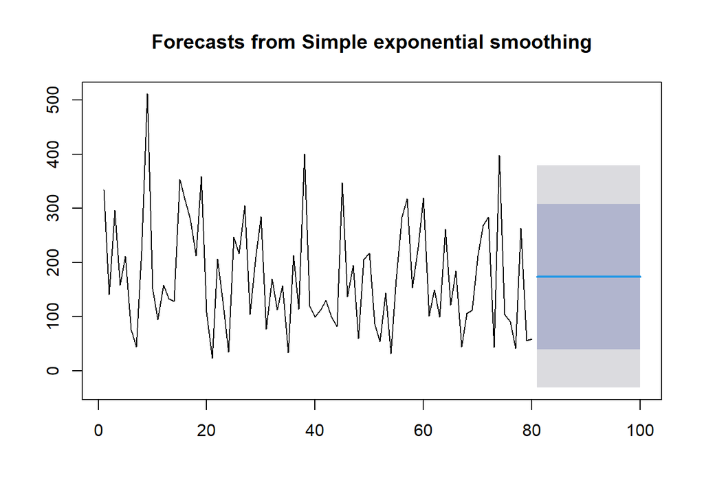

```r
#SES
ses.opt <- ses(train_ses.ts, h = 20, alpha = NULL)
plot(ses.opt)
```

```r
ses.opt
```

```
##     Point Forecast    Lo 80    Hi 80     Lo 95    Hi 95
##  81       174.0721 39.83879 308.3053 -31.22000 379.3641
##  82       174.0721 39.83879 308.3053 -31.22000 379.3641
##  83       174.0721 39.83879 308.3053 -31.22000 379.3641
##  84       174.0721 39.83879 308.3053 -31.22000 379.3641
##  85       174.0721 39.83879 308.3053 -31.22000 379.3641
##  86       174.0721 39.83879 308.3053 -31.22000 379.3641
##  87       174.0721 39.83879 308.3053 -31.22001 379.3641
##  88       174.0721 39.83879 308.3053 -31.22001 379.3641
##  89       174.0721 39.83879 308.3053 -31.22001 379.3641
##  90       174.0721 39.83879 308.3053 -31.22001 379.3641
##  91       174.0721 39.83879 308.3053 -31.22001 379.3641
##  92       174.0721 39.83879 308.3053 -31.22001 379.3641
##  93       174.0721 39.83879 308.3053 -31.22001 379.3641
##  94       174.0721 39.83879 308.3053 -31.22001 379.3641
##  95       174.0721 39.83879 308.3053 -31.22001 379.3641
##  96       174.0721 39.83878 308.3053 -31.22001 379.3641
##  97       174.0721 39.83878 308.3053 -31.22002 379.3641
##  98       174.0721 39.83878 308.3053 -31.22002 379.3641
##  99       174.0721 39.83878 308.3053 -31.22002 379.3641
## 100       174.0721 39.83878 308.3053 -31.22002 379.3641
```

```r
#Lamda Optimum Holt Winter
sesopt<- HoltWinters(train_ses.ts, gamma = FALSE, beta = FALSE,alpha = NULL)
sesopt
```

```
## Holt-Winters exponential smoothing without trend and without seasonal component.
##
## Call:
## HoltWinters(x = train_ses.ts, alpha = NULL, beta = FALSE, gamma = FALSE)
##
## Smoothing parameters:
##  alpha: 0.1268285
##  beta : FALSE
##  gamma: FALSE
##
## Coefficients:
##       [,1]
## a 142.7177
```

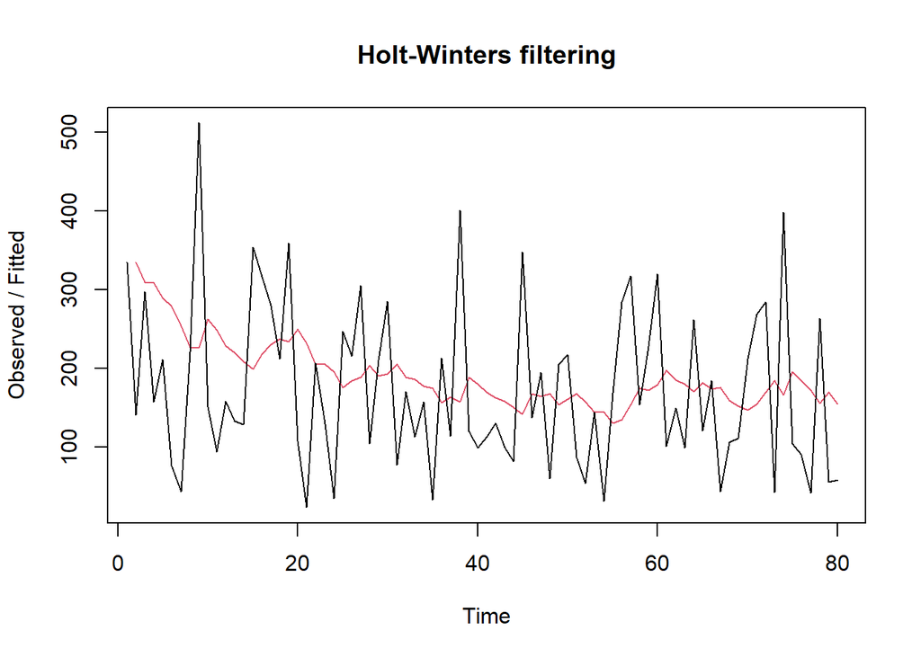

```r
plot(sesopt)
```

```r
#ramalan
ramalanopt<- forecast(sesopt, h=20)
ramalanopt
```

```
##     Point Forecast       Lo 80    Hi 80      Lo 95    Hi 95
##  81       142.7177   0.3819808 285.0534  -74.96600 360.4014
##  82       142.7177  -0.7582209 286.1936  -76.70979 362.1452
##  83       142.7177  -1.8894326 287.3248  -78.43982 363.8752
##  84       142.7177  -3.0118636 288.4473  -80.15643 365.5918
##  85       142.7177  -4.1257154 289.5611  -81.85992 367.2953
##  86       142.7177  -5.2311816 290.6666  -83.55059 368.9860
##  87       142.7177  -6.3284488 291.7638  -85.22871 370.6641
##  88       142.7177  -7.4176969 292.8531  -86.89457 372.3300
##  89       142.7177  -8.4990991 293.9345  -88.54844 373.9838
##  90       142.7177  -9.5728225 295.0082  -90.19056 375.6260
##  91       142.7177 -10.6390285 296.0744  -91.82118 377.2566
##  92       142.7177 -11.6978727 297.1333  -93.44054 378.8759
##  93       142.7177 -12.7495056 298.1849  -95.04887 380.4843
##  94       142.7177 -13.7940725 299.2295  -96.64640 382.0818
##  95       142.7177 -14.8317140 300.2671  -98.23334 383.6687
##  96       142.7177 -15.8625660 301.2980  -99.80989 385.2453
##  97       142.7177 -16.8867601 302.3222 -101.37626 386.8117
##  98       142.7177 -17.9044237 303.3398 -102.93264 388.3680
##  99       142.7177 -18.9156800 304.3511 -104.47922 389.9146
## 100       142.7177 -19.9206487 305.3560 -106.01619 391.4516
```

Setelah dilakukan peramalan, akan dilakukan perhitungan keakuratan hasil peramalan. Perhitungan akurasi ini dilakukan baik pada data latih dan data uji.

```r
#Keakuratan Metode
#Pada data training
SSE1<-ses1$SSE
MSE1<-ses1$SSE/length(train_ses.ts)
RMSE1<-sqrt(MSE1)

akurasi1 <- matrix(c(SSE1,MSE1,RMSE1))
row.names(akurasi1)<- c("SSE", "MSE", "RMSE")
colnames(akurasi1) <- c("Akurasi lamda=0.2")
akurasi1
```

```
##      Akurasi lamda=0.2
## SSE        1008131.069
## MSE          12601.638
## RMSE           112.257
```

```r
SSE2<-ses2$SSE
MSE2<-ses2$SSE/length(train_ses.ts)
RMSE2<-sqrt(MSE2)

akurasi2 <- matrix(c(SSE2,MSE2,RMSE2))
row.names(akurasi2)<- c("SSE", "MSE", "RMSE")
colnames(akurasi2) <- c("Akurasi lamda=0.7")
akurasi2
```

```
##      Akurasi lamda=0.7
## SSE       1331536.7568
## MSE         16644.2095
## RMSE          129.0124
```

```r
#Cara Manual
fitted1<-ramalan1$fitted
sisaan1<-ramalan1$residuals
head(sisaan1)
```

```
## Time Series:
## Start = 1
## End = 6
## Frequency = 1
## [1]        NA -193.4000    1.2400 -138.0280  -57.1024 -180.2819
```

```r
resid1<-training$daily_revenue-ramalan1$fitted
head(resid1)
```

```
## Time Series:
## Start = 1
## End = 6
## Frequency = 1
## [1]        NA -193.4000    1.2400 -138.0280  -57.1024 -180.2819
```

```r
#Cara Manual
SSE.1=sum(sisaan1[2:length(train_ses.ts)]^2)
SSE.1
```

```
## [1] 1008131
```

```r
MSE.1 = SSE.1/length(train_ses.ts)
MSE.1
```

```
## [1] 12601.64
```

```r
MAPE.1 = sum(abs(sisaan1[2:length(train_ses.ts)]/train.ts[2:length(train_ses.ts)])*
               100)/length(train_ses.ts)
MAPE.1
```

```
## [1] 95.12225
```

```r
akurasi.1 <- matrix(c(SSE.1,MSE.1,MAPE.1))
row.names(akurasi.1)<- c("SSE", "MSE", "MAPE")
colnames(akurasi.1) <- c("Akurasi lamda=0.2")
akurasi.1
```

```
##      Akurasi lamda=0.2
## SSE       1.008131e+06
## MSE       1.260164e+04
## MAPE      9.512225e+01
```

```r
fitted2<-ramalan2$fitted
sisaan2<-ramalan2$residuals
head(sisaan2)
```

```
## Time Series:
## Start = 1
## End = 6
## Frequency = 1
## [1]        NA -193.4000   97.9400 -109.6380   20.4286 -128.4714
```

```r
resid2<-training$daily_revenue-ramalan2$fitted
head(resid2)
```

```
## Time Series:
## Start = 1
## End = 6
## Frequency = 1
## [1]        NA -193.4000   97.9400 -109.6380   20.4286 -128.4714
```

```r
SSE.2=sum(sisaan2[2:length(train_ses.ts)]^2)
SSE.2
```

```
## [1] 1331537
```

```r
MSE.2 = SSE.2/length(train_ses.ts)
MSE.2
```

```
## [1] 16644.21
```

```r
MAPE.2 = sum(abs(sisaan2[2:length(train_ses.ts)]/train.ts[2:length(train_ses.ts)])*
               100)/length(train_ses.ts)
MAPE.2
```

```
## [1] 94.76958
```

```r
akurasi.2 <- matrix(c(SSE.2,MSE.2,MAPE.2))
row.names(akurasi.2)<- c("SSE", "MSE", "MAPE")
colnames(akurasi.2) <- c("Akurasi lamda=0.7")
akurasi.2
```

```
##      Akurasi lamda=0.7
## SSE       1.331537e+06
## MSE       1.664421e+04
## MAPE      9.476958e+01
```

```r
#cara lain
accuracy(ramalanopt,testing$daily_revenue)
```

```
##                     ME      RMSE      MAE        MPE     MAPE      MASE
## Training set -19.12303 112.00452 94.30302 -74.144252 98.65756 0.7982465
## Test set      42.78680  85.85762 70.07242   7.017375 37.88717 0.5931418
##                     ACF1
## Training set -0.01180667
## Test set              NA
```

Berdasarkan hasil pengujian kekuratan pada data latih dan data uji pada metode SES memberikan nilai MAPE yang tidak jauh berbeda dari metode SMA namun pada kedua metode ini nilai MAPE masih jauh diatas 10% yang mengindikasikan akurasi peramalan yang kurang baik. ## DES

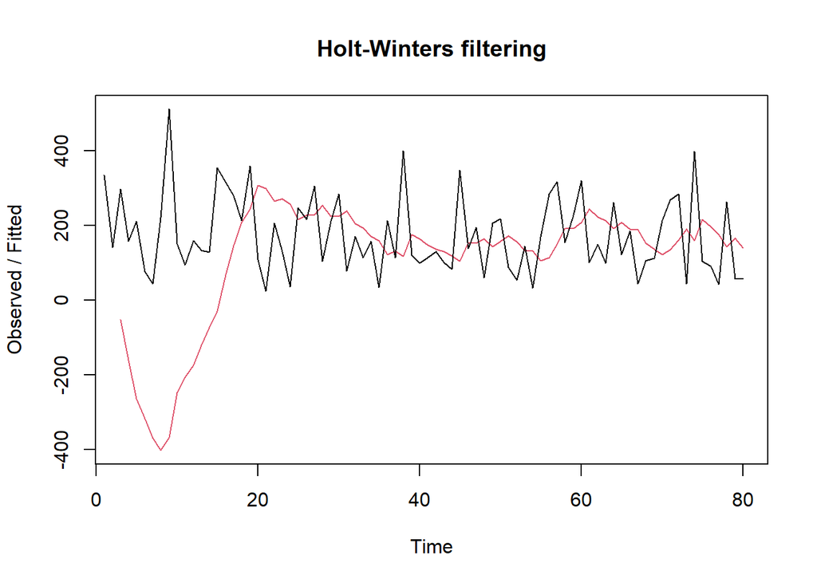

```r
#Lamda=0.2 dan gamma=0.2
des.1<- HoltWinters(train_ses.ts, gamma = FALSE, beta = 0.2, alpha = 0.2)
plot(des.1)
```

```r
#ramalan
ramalandes1<- forecast(des.1, h=20)
ramalandes1
```

```
##     Point Forecast     Lo 80    Hi 80      Lo 95     Hi 95
##  81     114.317192 -146.7717 375.4061  -284.9838  513.6182
##  82     105.803383 -162.6996 374.3064  -304.8365  516.4433
##  83      97.289574 -180.9876 375.5667  -328.2986  522.8778
##  84      88.775765 -201.7729 379.3244  -355.5801  533.1316
##  85      80.261956 -225.1116 385.6355  -386.7666  547.2905
##  86      71.748147 -250.9898 394.4861  -421.8370  565.3333
##  87      63.234338 -279.3398 405.8084  -460.6875  587.1562
##  88      54.720529 -310.0572 419.4983  -503.1589  612.5999
##  89      46.206720 -343.0172 435.4306  -549.0599  641.4733
##  90      37.692911 -378.0865 453.4724  -598.1869  673.5727
##  91      29.179101 -415.1325 473.4907  -650.3369  708.6951
##  92      20.665292 -454.0285 495.3591  -705.3162  746.6468
##  93      12.151483 -494.6570 518.9599  -762.9452  787.2481
##  94       3.637674 -536.9109 544.1863  -823.0601  830.3354
##  95      -4.876135 -580.6941 570.9418  -885.5137  875.7614
##  96     -13.389944 -625.9203 599.1404  -950.1743  923.3944
##  97     -21.903753 -672.5130 628.7055 -1016.9247  973.1172
##  98     -30.417562 -720.4039 659.5688 -1085.6607 1024.8256
##  99     -38.931371 -769.5326 691.6698 -1156.2895 1078.4267
## 100     -47.445180 -819.8448 724.9545 -1228.7285 1133.8381
```

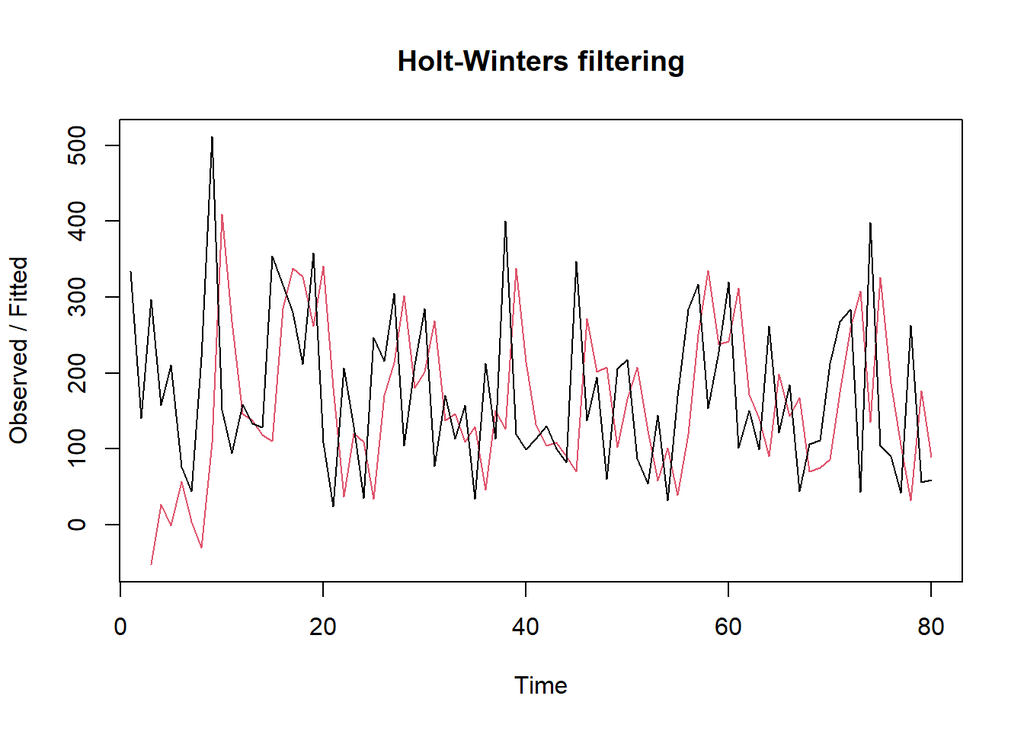

```r
#Lamda=0.6 dan gamma=0.3
des.2<- HoltWinters(train_ses.ts, gamma = FALSE, beta = 0.3, alpha = 0.6)
plot(des.2)
```

```r
#ramalan
ramalandes2<- forecast(des.2, h=20)
ramalandes2
```

```
##     Point Forecast      Lo 80     Hi 80      Lo 95     Hi 95
##  81      49.923464  -138.4427  238.2897  -238.1578  338.0047
##  82      29.049889  -209.8412  267.9410  -336.3025  394.4023
##  83       8.176315  -291.4385  307.7911  -450.0449  466.3976
##  84     -12.697259  -381.3179  355.9234  -576.4539  551.0594
##  85     -33.570833  -478.2108  411.0692  -713.5890  646.4474
##  86     -54.444407  -581.2639  472.3751  -860.1454  751.2566
##  87     -75.317982  -689.8770  539.2410 -1015.2048  864.5689
##  88     -96.191556  -803.6063  611.2232 -1178.0891  985.7060
##  89    -117.065130  -922.1097  687.9795 -1348.2746 1114.1443
##  90    -137.938704 -1045.1131  769.2357 -1525.3423 1249.4648
##  91    -158.812278 -1172.3905  854.7659 -1708.9463 1391.3218
##  92    -179.685853 -1303.7508  944.3791 -1898.7948 1539.4231
##  93    -200.559427 -1439.0296 1037.9107 -2094.6361 1693.5172
##  94    -221.433001 -1578.0829 1135.2169 -2296.2500 1853.3840
##  95    -242.306575 -1720.7832 1236.1701 -2503.4415 2018.8284
##  96    -263.180150 -1867.0163 1340.6560 -2716.0358 2189.6755
##  97    -284.053724 -2016.6787 1448.5713 -2933.8750 2365.7676
##  98    -304.927298 -2169.6765 1559.8219 -3156.8152 2546.9606
##  99    -325.800872 -2325.9235 1674.3218 -3384.7245 2733.1227
## 100    -346.674446 -2485.3402 1791.9913 -3617.4814 2924.1325
```

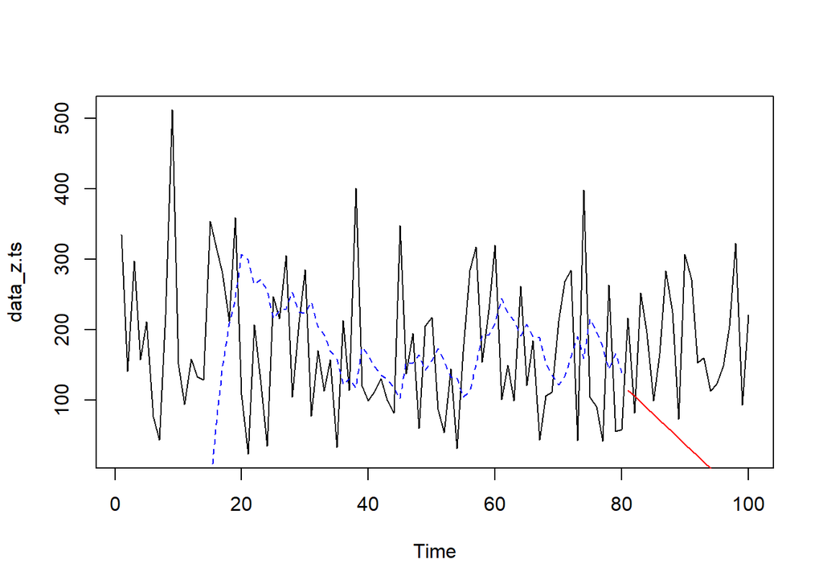

```r
#Visually evaluate the prediction
plot(data_z.ts)
lines(des.1$fitted[,1], lty=2, col="blue")
lines(ramalandes1$mean, col="red")
```

```r
#Lamda dan gamma optimum
des.opt<- HoltWinters(train_ses.ts, gamma = FALSE)
des.opt
```

```
## Holt-Winters exponential smoothing with trend and without seasonal component.
##
## Call:
## HoltWinters(x = train_ses.ts, gamma = FALSE)
##
## Smoothing parameters:
##  alpha: 0.4962747
##  beta : 0.3014193
##  gamma: FALSE
##
## Coefficients:
##        [,1]
## a  75.30905
## b -20.62356
```

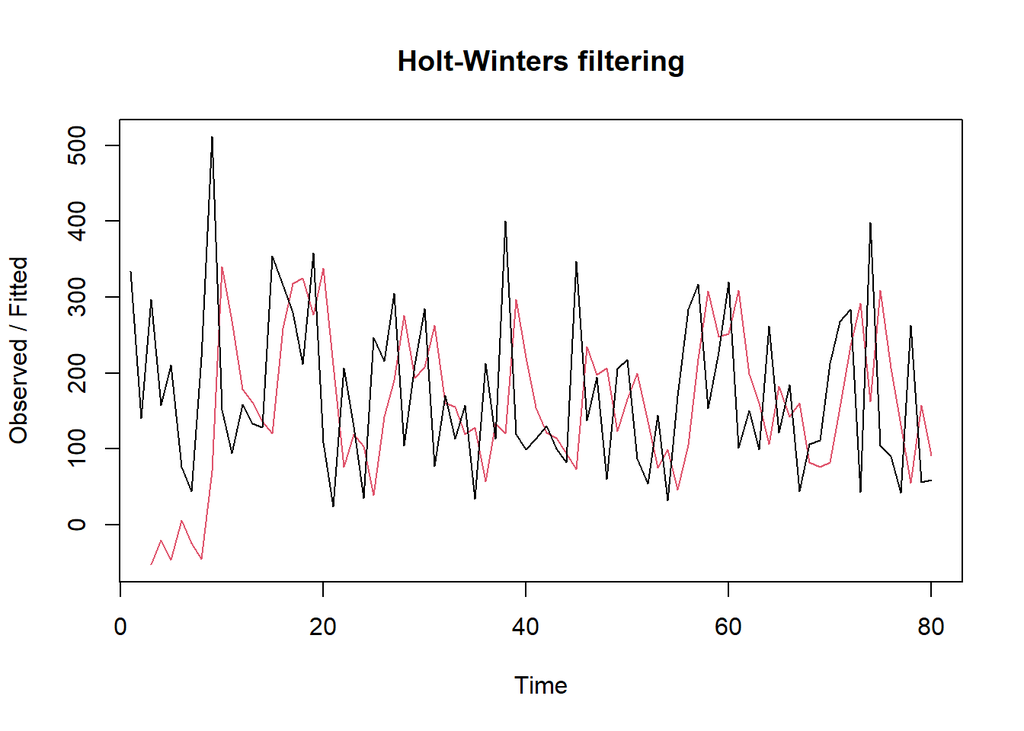

```r
plot(des.opt)
```

```r
#ramalan
ramalandesopt<- forecast(des.opt, h=20)
ramalandesopt
```

```
##     Point Forecast      Lo 80     Hi 80      Lo 95     Hi 95
##  81      54.685491  -131.3221  240.6930  -229.7885  339.1595
##  82      34.061934  -187.3681  255.4919  -304.5860  372.7099
##  83      13.438376  -252.8758  279.7525  -393.8540  420.7307
##  84      -7.185181  -326.2825  311.9122  -495.2024  480.8321
##  85     -27.808738  -406.3312  350.7138  -606.7090  551.0915
##  86     -48.432295  -492.0990  395.2344  -726.9620  630.0974
##  87     -69.055853  -582.9177  444.8060  -854.9398  716.8281
##  88     -89.679410  -678.2959  498.9371  -989.8906  810.5318
##  89    -110.302967  -777.8616  557.2557 -1131.2458  910.6398
##  90    -130.926524  -881.3250  619.4719 -1278.5619 1016.7089
##  91    -151.550082  -988.4537  685.3536 -1431.4838 1128.3836
##  92    -172.173639 -1099.0569  754.7096 -1589.7193 1245.3720
##  93    -192.797196 -1212.9740  827.3796 -1753.0230 1367.4286
##  94    -213.420753 -1330.0678  903.2263 -1921.1851 1494.3436
##  95    -234.044311 -1450.2189  982.1303 -2094.0228 1625.9342
##  96    -254.667868 -1573.3221 1063.9864 -2271.3755 1762.0398
##  97    -275.291425 -1699.2838 1148.7010 -2453.0999 1902.5170
##  98    -295.914983 -1828.0197 1236.1897 -2639.0670 2047.2370
##  99    -316.538540 -1959.4533 1326.3762 -2829.1599 2196.0828
## 100    -337.162097 -2093.5149 1419.1907 -3023.2719 2348.9477
```

```r
#Akurasi Data Training
ssedes.train1<-des.1$SSE
msedes.train1<-ssedes.train1/length(train_ses.ts)
sisaandes1<-ramalandes1$residuals
head(sisaandes1)
```

```
## Time Series:
## Start = 1
## End = 6
## Frequency = 1
## [1]       NA       NA 349.3600 319.8936 475.8647 393.6871
```

```r
mapedes.train1 <- sum(abs(sisaandes1[3:length(train_ses.ts)]/train_ses.ts[3:length(train_ses.ts)])
                      *100)/length(train_ses.ts)

akurasides.1 <- matrix(c(ssedes.train1,msedes.train1,mapedes.train1))
row.names(akurasides.1)<- c("SSE", "MSE", "MAPE")
colnames(akurasides.1) <- c("Akurasi lamda=0.2 dan gamma=0.2")
akurasides.1
```

```
##      Akurasi lamda=0.2 dan gamma=0.2
## SSE                     3469817.5396
## MSE                       43372.7192
## MAPE                        133.3512
```

```r
ssedes.train2<-des.2$SSE
msedes.train2<-ssedes.train2/length(train_ses.ts)
sisaandes2<-ramalandes2$residuals
head(sisaandes2)
```

```
## Time Series:
## Start = 1
## End = 6
## Frequency = 1
## [1]        NA        NA 349.36000 131.23920 212.70782  19.08787
```

```r
mapedes.train2 <- sum(abs(sisaandes2[3:length(train_ses.ts)]/train_ses.ts[3:length(train_ses.ts)])
                      *100)/length(train_ses.ts)

akurasides.2 <- matrix(c(ssedes.train2,msedes.train2,mapedes.train2))
row.names(akurasides.2)<- c("SSE", "MSE", "MAPE")
colnames(akurasides.2) <- c("Akurasi lamda=0.6 dan gamma=0.3")
akurasides.2
```

```
##      Akurasi lamda=0.6 dan gamma=0.3
## SSE                     1.675284e+06
## MSE                     2.094106e+04
## MAPE                    9.486572e+01
```

Hasil akurasi dari data latih didapatkan skenario 2 dengan lamda=0.6 dan gamma=0.3 memiliki hasil yang lebih baik. Namun untuk kedua skenario tidak dapat dikategorikan peramalan dengan akurasi yang baik berdasarkan nilai MAPE-nya.

```r
#Akurasi Data Testing
selisihdes1<-ramalandes1$mean-testing$daily_revenue
selisihdes1
```

```
## Time Series:
## Start = 81
## End = 100
## Frequency = 1
##  [1] -102.04281   23.66338 -154.81043 -106.92423  -19.13804  -94.64185
##  [7] -219.89566 -169.76947  -26.67328 -269.12709 -241.90090 -132.52471
## [13] -148.13852 -109.83233 -127.23613 -162.45994 -226.95375 -352.96756
## [19] -132.13137 -267.86518
```

```r
SSEtestingdes1<-sum(selisihdes1^2)
MSEtestingdes1<-SSEtestingdes1/length(testing$daily_revenue)
MAPEtestingdes1<-sum(abs(selisihdes1/testing$daily_revenue)*100)/length(testing$daily_revenue)

selisihdes2<-ramalandes2$mean-testing$daily_revenue
selisihdes2
```

```
## Time Series:
## Start = 81
## End = 100
## Frequency = 1
##  [1] -166.43654  -53.09011 -243.92368 -208.39726 -132.97083 -220.83441
##  [7] -358.44798 -320.68156 -189.94513 -444.75870 -429.89228 -332.87585
## [13] -360.84943 -334.90300 -364.66658 -412.25015 -489.10372 -627.47730
## [19] -419.00087 -567.09445
```

```r
SSEtestingdes2<-sum(selisihdes2^2)
MSEtestingdes2<-SSEtestingdes2/length(testing$daily_revenue)
MAPEtestingdes2<-sum(abs(selisihdes2/testing$daily_revenue)*100)/length(testing$daily_revenue)

selisihdesopt<-ramalandesopt$mean-testing$daily_revenue
selisihdesopt
```

```
## Time Series:
## Start = 81
## End = 100
## Frequency = 1
##  [1] -161.67451  -48.07807 -238.66162 -202.88518 -127.20874 -214.82230
##  [7] -352.18585 -314.16941 -183.18297 -437.74652 -422.63008 -325.36364
## [13] -353.08720 -326.89075 -356.40431 -403.73787 -480.34143 -618.46498
## [19] -409.73854 -557.58210
```

```r
SSEtestingdesopt<-sum(selisihdesopt^2)
MSEtestingdesopt<-SSEtestingdesopt/length(testing$daily_revenue)
MAPEtestingdesopt<-sum(abs(selisihdesopt/testing$daily_revenue)*100)/length(testing$daily_revenue)

akurasitestingdes <-
  matrix(c(SSEtestingdes1,MSEtestingdes1,MAPEtestingdes1,SSEtestingdes2,MSEtestingdes2,
           MAPEtestingdes2,SSEtestingdesopt,MSEtestingdesopt,MAPEtestingdesopt),
         nrow=3,ncol=3)
row.names(akurasitestingdes)<- c("SSE", "MSE", "MAPE")
colnames(akurasitestingdes) <- c("des ske1","des ske2","des opt")
akurasitestingdes
```

```
##          des ske1     des ske2      des opt
## SSE  623985.55564 2636133.9976 2534862.3088
## MSE   31199.27778  131806.6999  126743.1154
## MAPE     80.35453     194.8488     190.2207
```

Sama seperti nilai pada akurasi data latih , pada data uji nilai MAPE yang didapat juga masih diatas 10%.

Hasil ini juga sebenarnya sesuai dugaan yaitu metode SES akan memberikan akurasi yang lebih baik dikarenakan pola data yang terlihat konstan.

Dari 4 metode sebelumnya belum memberikan peramalan dengan akurasi yang baik, selanjutnya akan dilakukan pemulusan untuk data musiman (dilakukan metode ini karena mungkin saja data keuntungan harian ini sebenarnya memiliki pola musiman yang tidak tertangkap oleh mata). # Winter Aditif & Winter Multiaplikatif

```r
#membagi data menjadi training dan testing
training<-data_z[1:80,2]
testing<-data_z[81:100,2]
training.ts<-ts(training, frequency = 14)
testing.ts<-ts(testing, frequency = 14)
```

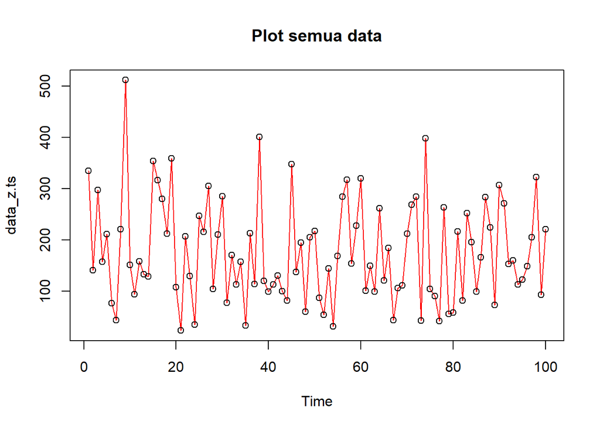

```r
#Membuat plot time series
plot(data_z.ts, col="red",main="Plot semua data")
points(data_z.ts)
```

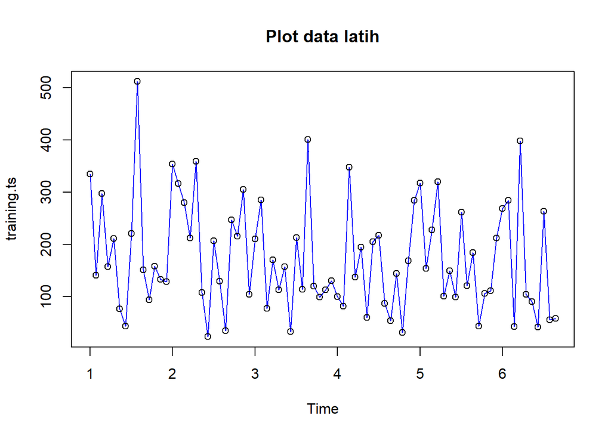

```r
plot(training.ts, col="blue",main="Plot data latih")
points(training.ts)
```

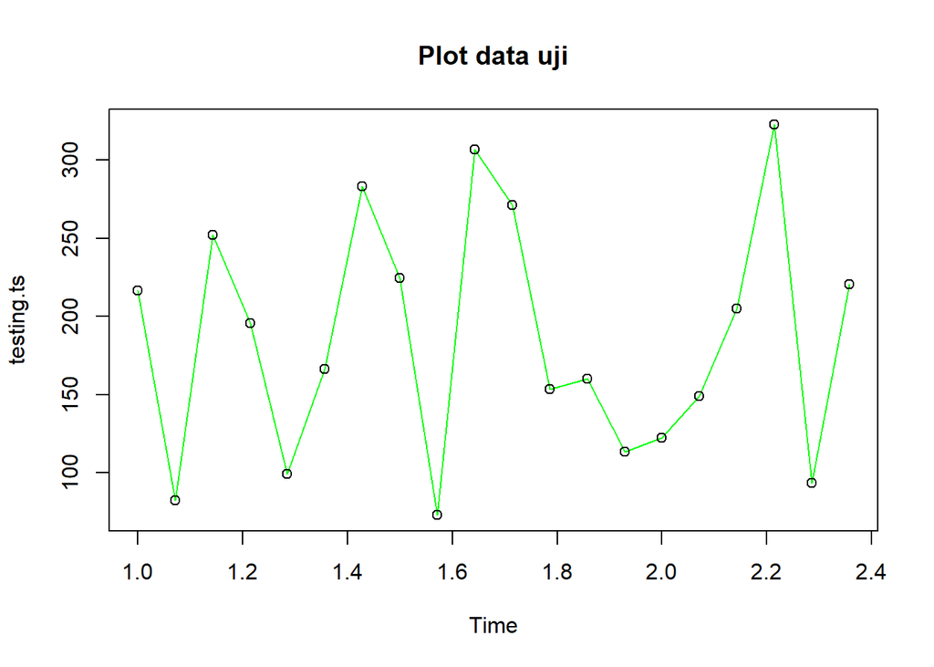

```r
plot(testing.ts, col="green",main="Plot data uji")
points(testing.ts)
```

# winter aditif

```r
#Pemulusan dengan winter aditif
winter1 <- HoltWinters(training.ts,alpha=0.2,beta=0.1,gamma=0.1,seasonal = "additive")
winter1$fitted
```

```
## Time Series:
## Start = c(2, 1)
## End = c(6, 10)
## Frequency = 14
##                 xhat     level       trend      season
## 2.000000 326.1721071 204.86292 -0.24262402  121.551811
## 2.071429 308.3136196 210.15587  0.31093384   97.846811
## 2.142857 291.8926999 212.00408  0.46466145   79.423954
## 2.214286 220.7436388 210.04621  0.22240745   10.475026
## 2.285714 358.1521172 208.54589  0.05013467  149.556097
## 2.357143  99.6511146 208.70960  0.06149233 -109.119974
## 2.428571  11.6028760 210.48887  0.23327004 -199.119260
## 2.500000 229.0571991 213.10556  0.47161252   15.480026
## 2.571429 508.0116706 209.14373  0.02826853  298.839668
## 2.642857  59.2340288 133.47767 -7.54116488  -66.702474
## 2.714286 -12.1073224 121.09770 -8.02504545 -125.179974
## 2.785714  93.8733430 164.93012 -2.83929901  -68.217474
## 2.857143  86.3187086 186.50415 -0.39796587  -99.787474
## 2.928571 128.8637411 229.92644  3.98405996 -105.046760
## 3.000000 356.2433809 228.98575  3.49158514  123.766043
## 3.071429 302.4265012 203.38266  0.58211752   98.461722
## 3.142857 279.1460049 200.45948  0.23158750   78.454938
## 3.214286 166.3178676 160.33587 -3.80393260    9.785934
## 3.285714 303.2033973 157.32636 -3.72448995  149.601528
## 3.357143  -0.4376313 115.52719 -7.53195790 -108.432864
## 3.428571 -63.0289369 139.51676 -4.37980527 -198.165890
## 3.500000 165.7221638 154.46274 -2.44722654   13.706650
## 3.571429 428.5049464 161.44708 -1.50406981  268.561935
## 3.642857  20.5372568  96.97602 -7.80076874  -68.637997
## 3.714286  60.5160997 165.15580 -0.20271388 -104.436989
## 3.785714 119.3186906 176.78987  0.98096413  -58.452142
## 3.857143  92.1191136 173.79509  0.58339032  -82.259371
## 3.928571  72.5918106 178.60266  1.00580804 -107.016659
## 4.000000 305.4294520 191.14211  2.15917183  112.128172
## 4.071429 247.3695738 152.25539 -1.94541721   97.059602
## 4.142857 174.2609065 117.20406 -5.25600868   62.312858
## 4.214286 154.8577457 146.54987 -1.79582681   10.103705
## 4.285714 273.4165656 141.19649 -2.15158172  134.371656
## 4.357143  23.8306305 123.37360 -3.71871304  -95.824253
## 4.428571 -66.5597434 126.87276 -2.99692565 -190.435575
```

[output cut: 16 more lines]

```
## 5.642857 109.2563506 151.50608 -2.19466479  -40.055068
## 5.714286  75.0497985 164.38015 -0.68779181  -88.642558
## 5.785714  92.9675963 157.48240 -1.30878778  -63.206013
## 5.857143  87.4502787 158.78009 -1.04813970  -70.281672
## 5.928571  78.7315958 162.54189 -0.56714528  -83.243153
## 6.000000 288.2896146 188.70843  2.10622281   97.474962
## 6.071429 261.1941628 186.79873  1.70463052   72.690802
## 6.142857 268.8875781 193.12653  2.16694726   73.594103
## 6.214286 166.9852488 150.11796 -2.35060430   19.217894
## 6.285714 305.3591155 193.96431  2.26909072  109.125719
## 6.357143  67.7954337 156.04157 -1.75009159  -86.496048
## 6.428571  -4.0373244 158.86439 -1.29280026 -161.608919
## 6.500000 188.7305614 166.73906 -0.37605377   22.367556
## 6.571429 373.6156597 181.24889  1.11253500  191.254231
## 6.642857  79.5841421 118.85030 -5.23857820  -34.027576
```

```r
xhat1 <- winter1$fitted[,2]

winter1.opt<- HoltWinters(training.ts, alpha= NULL,  beta = NULL, gamma = NULL, seasonal = "additive")
winter1.opt
```

```
## Holt-Winters exponential smoothing with trend and additive seasonal component.
##
## Call:
## HoltWinters(x = training.ts, alpha = NULL, beta = NULL, gamma = NULL,     seasonal = "additive")
##
## Smoothing parameters:
##  alpha: 0
##  beta : 0
##  gamma: 0.5102256
##
## Coefficients:
##            [,1]
## a    188.849735
## b     -0.242624
## s1  -102.527473
## s2   -99.782696
## s3   -57.230872
## s4    12.895876
## s5    66.507544
## s6    34.554798
## s7   -51.345915
## s8   128.826341
## s9   -63.495389
## s10  -86.553966
## s11 -118.481908
## s12   58.827600
## s13  -97.863629
## s14  -80.441578
```

```r
winter1.opt$fitted
```

```
## Time Series:
## Start = c(2, 1)
## End = c(6, 10)
## Frequency = 14
##                xhat    level     trend      season
## 2.000000 326.172107 204.8629 -0.242624  121.551811
## 2.071429 302.224483 204.6203 -0.242624   97.846811
## 2.142857 283.559002 204.3777 -0.242624   79.423954
## 2.214286 214.367449 204.1350 -0.242624   10.475026
## 2.285714 353.205897 203.8924 -0.242624  149.556097
## 2.357143  94.287201 203.6498 -0.242624 -109.119974
## 2.428571   4.045292 203.4072 -0.242624 -199.119260
## 2.500000 218.401953 203.1646 -0.242624   15.480026
## 2.571429 501.518972 202.9219 -0.242624  298.839668
## 2.642857 135.734205 202.6793 -0.242624  -66.702474
## 2.714286  77.014081 202.4367 -0.242624 -125.179974
## 2.785714 133.733957 202.1941 -0.242624  -68.217474
## 2.857143 101.921333 201.9514 -0.242624  -99.787474
## 2.928571  96.419423 201.7088 -0.242624 -105.046760
## 3.000000 336.897342 201.4662 -0.242624  135.673782
## 3.071429 305.856369 201.2236 -0.242624  104.875433
## 3.142857 278.234122 200.9809 -0.242624   77.495810
## 3.214286 209.829109 200.7383 -0.242624    9.333421
## 3.285714 352.622597 200.4957 -0.242624  152.369534
## 3.357143  98.009541 200.2531 -0.242624 -102.000899
## 3.428571  10.585051 200.0104 -0.242624 -189.182765
## 3.500000 209.131523 199.7678 -0.242624    9.606332
## 3.571429 308.329025 199.5252 -0.242624  109.046457
## 3.642857  80.960703 199.2826 -0.242624 -118.079240
## 3.714286 160.440361 199.0399 -0.242624  -38.356959
## 3.785714 172.280852 198.7973 -0.242624  -26.273843
## 3.857143 202.354835 198.5547 -0.242624    4.042764
## 3.928571  97.012946 198.3121 -0.242624 -101.056501
## 4.000000 269.147201 198.0694 -0.242624   71.320378
## 4.071429 291.767156 197.8268 -0.242624   94.182956
## 4.142857 172.351360 197.5842 -0.242624  -24.990216
## 4.214286 186.258505 197.3416 -0.242624  -10.840446
## 4.285714 226.877528 197.0990 -0.242624   30.021201
## 4.357143 124.797988 196.8563 -0.242624  -71.815715
## 4.428571  18.931132 196.6137 -0.242624 -177.439947
```

[output cut: 16 more lines]

```
## 5.642857 141.827641 192.4891 -0.242624  -50.418830
## 5.714286 136.851684 192.2465 -0.242624  -55.152163
## 5.785714  77.371565 192.0038 -0.242624 -114.389658
## 5.857143 158.026991 191.7612 -0.242624  -33.491608
## 5.928571 195.600123 191.5186 -0.242624    4.324148
## 6.000000 246.426284 191.2760 -0.242624   55.392934
## 6.071429 163.918895 191.0334 -0.242624  -26.871832
## 6.142857 239.411029 190.7907 -0.242624   48.862926
## 6.214286 237.001629 190.5481 -0.242624   46.696150
## 6.285714 149.660569 190.3055 -0.242624  -40.402286
## 6.357143 116.398924 190.0629 -0.242624  -73.421307
## 6.428571 101.614685 189.8202 -0.242624  -87.962922
## 6.500000 232.538924 189.5776 -0.242624   43.203941
## 6.571429 127.865983 189.3350 -0.242624  -61.226375
## 6.642857 160.254459 189.0924 -0.242624  -28.595276
```

```r
xhat1.opt <- winter1.opt$fitted[,2]
```

```r
#Forecast
forecast1 <- predict(winter1, n.ahead = 20)
forecast1.opt <- predict(winter1.opt, n.ahead = 20)
```

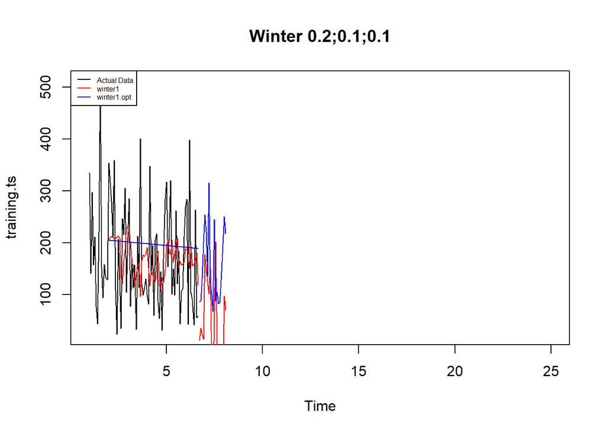

```r
#Plot time series
plot(training.ts,main="Winter 0.2;0.1;0.1",type="l",col="black",
     xlim=c(1,25),pch=12)
lines(xhat1,type="l",col="red")
lines(xhat1.opt,type="l",col="blue")
lines(forecast1,type="l",col="red")
lines(forecast1.opt,type="l",col="blue")
legend("topleft",c("Actual Data",expression(paste(winter1)),
                   expression(paste(winter1.opt))),cex=0.5,
       col=c("black","red","blue"),lty=1)
```

```r
#Akurasi data training
SSE1<-winter1$SSE
MSE1<-winter1$SSE/length(training.ts)
RMSE1<-sqrt(MSE1)
akurasi1 <- matrix(c(SSE1,MSE1,RMSE1))
row.names(akurasi1)<- c("SSE", "MSE", "RMSE")
colnames(akurasi1) <- c("Akurasi")
akurasi1
```

```
##           Akurasi
## SSE  1542747.8717
## MSE    19284.3484
## RMSE     138.8681
```

```r
SSE1.opt<-winter1.opt$SSE
MSE1.opt<-winter1.opt$SSE/length(training.ts)
RMSE1.opt<-sqrt(MSE1.opt)
akurasi1.opt <- matrix(c(SSE1.opt,MSE1.opt,RMSE1.opt))
row.names(akurasi1.opt)<- c("SSE1.opt", "MSE1.opt", "RMSE1.opt")
colnames(akurasi1.opt) <- c("Akurasi")
akurasi1.opt
```

```
##               Akurasi
## SSE1.opt  919357.7429
## MSE1.opt   11491.9718
## RMSE1.opt    107.2006
```

```r
akurasi1.train = data.frame(Model_Winter = c("Winter 1","Winter1 optimal"),
                            Nilai_SSE=c(SSE1,SSE1.opt),
                            Nilai_MSE=c(MSE1,MSE1.opt),Nilai_RMSE=c(RMSE1,RMSE1.opt))
akurasi1.train
```

```
##      Model_Winter Nilai_SSE Nilai_MSE Nilai_RMSE
## 1        Winter 1 1542747.9  19284.35   138.8681
## 2 Winter1 optimal  919357.7  11491.97   107.2006
```

```r
#Akurasi Data Testing
forecast1<-data.frame(forecast1)
testing.ts<-data.frame(testing.ts)
selisih1<-forecast1-testing.ts
SSEtesting1<-sum(selisih1^2)
MSEtesting1<-SSEtesting1/length(testing.ts)

forecast1.opt<-data.frame(forecast1.opt)
selisih1.opt<-forecast1.opt-testing.ts
SSEtesting1.opt<-sum(selisih1.opt^2)
MSEtesting1.opt<-SSEtesting1.opt/length(testing.ts)
```

```r
hasil <- data.frame(
  Model = c("Winter1", "Winter1.opt"),
  SSE   = c(SSEtesting1, SSEtesting1.opt),
  MSE   = c(MSEtesting1, MSEtesting1.opt)
)

print(hasil)
```

```
##         Model      SSE      MSE
## 1     Winter1 777183.3 777183.3
## 2 Winter1.opt 241387.0 241387.0
```

Baik data latih maupun data uji menghasilkan nilai MSE yang sangat tinggi yang dapat dikategorikan sebagai akurasi peramalan yang kurang baik. # winter multiaplikatif

```r
#Pemulusan dengan winter multiplikatif
winter2 <- HoltWinters(training.ts,alpha=0.2,beta=0.1,gamma=0.3,seasonal = "multiplicative")
winter2$fitted
```

```
## Time Series:
## Start = c(2, 1)
## End = c(6, 10)
## Frequency = 14
##               xhat    level       trend    season
## 2.000000 306.33513 204.8629 -0.24262402 1.4970906
## 2.071429 302.24201 210.9679  0.39213876 1.4299864
## 2.142857 296.75734 213.2843  0.58456008 1.3875670
## 2.214286 221.23599 211.4218  0.33985348 1.0447407
## 2.285714 356.97955 210.0184  0.16553295 1.6984149
## 2.357143 103.54694 210.3889  0.18602793 0.4917344
## 2.428571  22.16650 212.4837  0.37690555 0.1041362
## 2.500000 230.42195 215.4601  0.63685383 1.0662897
## 2.571429 504.20759 211.6831  0.19547385 2.3797002
## 2.642857 121.61730 180.3900 -2.95338998 0.6854127
## 2.714286  62.21108 152.1738 -5.47967218 0.4240871
## 2.785714 163.23876 233.9257  3.24348395 0.6882799
## 2.857143 144.58306 252.4830  4.77487376 0.5620160
## 2.928571 175.67257 314.4936 10.49844580 0.5405442
## 3.000000 475.29799 298.5622  7.85545837 1.5511442
## 3.071429 400.04028 272.3102  4.44471182 1.4454677
## 3.142857 360.78553 260.8237  2.85159038 1.3682948
## 3.214286 228.54473 222.2492 -1.29101875 1.0343348
## 3.285714 352.45310 209.6940 -2.41743795 1.7004003
## 3.357143  86.41274 179.0922 -5.23586964 0.4970352
## 3.428571  21.12237 202.3281 -2.38869681 0.1056439
## 3.500000 232.38915 223.5614 -0.02649119 1.0396099
## 3.571429 412.70275 219.7818 -0.40180793 1.8812234
## 3.642857 100.99593 187.5887 -3.58093865 0.5488678
## 3.714286 184.43490 293.1211  7.33039775 0.6138591
## 3.785714 210.12814 279.3604  5.22128524 0.7383755
## 3.857143 175.86119 254.6001  2.22313237 0.6847557
## 3.928571 115.43125 238.5332  0.39412405 0.4831229
## 4.000000 324.32629 245.0660  1.00799469 1.3180030
## 4.071429 280.85852 212.0640 -2.39300332 1.3395200
## 4.142857 185.45877 179.9561 -5.36449348 1.0622432
## 4.214286 196.18323 205.0576 -2.31789859 0.9676608
## 4.285714 257.90150 190.5219 -3.53967455 1.3792834
## 4.357143 100.75080 177.8700 -4.45089410 0.5809670
## 4.428571  18.27326 159.3630 -5.85650921 0.1190390
```

[output cut: 16 more lines]

```
## 5.642857 154.92201 258.1796 -2.26305545 0.6053615
## 5.714286 139.47534 265.7216 -1.28255087 0.5274386
## 5.785714 107.13478 228.2356 -4.90289078 0.4797093
## 5.857143 136.31787 222.8596 -4.95020212 0.6255712
## 5.928571 124.44792 209.9750 -5.74364865 0.6093479
## 6.000000 239.05449 233.0989 -2.85688764 1.0382747
## 6.071429 212.57475 235.8582 -2.29527302 0.9101392
## 6.142857 280.73170 249.3265 -0.71891527 1.1292162
## 6.214286 193.50904 206.5037 -4.92929941 0.9599880
## 6.285714 250.77941 244.1710 -0.66964298 1.0298892
## 6.357143 114.94288 215.0751 -3.51226745 0.5433037
## 6.428571  50.20965 202.6239 -4.40616442 0.2533056
## 6.500000 162.28143 191.5778 -5.07015708 0.8701061
## 6.571429 191.13354 209.6953 -2.75139241 0.9236008
## 6.642857 108.74418 177.6945 -5.67632563 0.6321667
```

```r
xhat2 <- winter2$fitted[,2]

winter2.opt<- HoltWinters(training.ts, alpha= NULL,  beta = NULL, gamma = NULL, seasonal = "multiplicative")
winter2.opt$fitted
```

```
## Time Series:
## Start = c(2, 1)
## End = c(6, 10)
## Frequency = 14
##               xhat    level     trend    season
## 2.000000 306.33513 204.8629 -0.242624 1.4970906
## 2.071429 292.25728 204.6203 -0.242624 1.4299864
## 2.142857 283.25106 204.3777 -0.242624 1.3875670
## 2.214286 213.01472 204.1350 -0.242624 1.0447407
## 2.285714 345.88185 203.8924 -0.242624 1.6984149
## 2.357143 100.02231 203.6498 -0.242624 0.4917344
## 2.428571  21.15679 203.4072 -0.242624 0.1041362
## 2.500000 216.37356 203.1646 -0.242624 1.0662897
## 2.571429 482.31597 202.9219 -0.242624 2.3797002
## 2.642857 138.75267 202.6793 -0.242624 0.6854127
## 2.714286  85.74790 202.4367 -0.242624 0.4240871
## 2.785714 138.99911 202.1941 -0.242624 0.6882799
## 2.857143 113.36357 201.9514 -0.242624 0.5620160
## 2.928571 108.90137 201.7088 -0.242624 0.5405442
## 3.000000 323.66935 201.4662 -0.242624 1.6085062
## 3.071429 298.60255 201.2236 -0.242624 1.4857257
## 3.142857 276.90014 200.9809 -0.242624 1.3794085
## 3.214286 209.04859 200.7383 -0.242624 1.0426588
## 3.285714 346.16986 200.4957 -0.242624 1.7286620
## 3.357143 102.22907 200.2531 -0.242624 0.5111187
## 3.428571  21.91799 200.0104 -0.242624 0.1097173
## 3.500000 208.27756 199.7678 -0.242624 1.0438660
## 3.571429 307.80566 199.5252 -0.242624 1.5445689
## 3.642857  87.49758 199.2826 -0.242624 0.4395981
## 3.714286 160.46217 199.0399 -0.242624 0.8071646
## 3.785714 172.95694 198.7973 -0.242624 0.8710796
## 3.857143 202.05248 198.5547 -0.242624 1.0188612
## 3.928571 104.86644 198.3121 -0.242624 0.5294428
## 4.000000 264.95037 198.0694 -0.242624 1.3393046
## 4.071429 287.09249 197.8268 -0.242624 1.4530134
## 4.142857 178.09898 197.5842 -0.242624 0.9024909
## 4.214286 187.22543 197.3416 -0.242624 0.9499058
## 4.285714 230.23938 197.0990 -0.242624 1.1695808
## 4.357143 126.40621 196.8563 -0.242624 0.6429166
## 4.428571  27.05509 196.6137 -0.242624 0.1377754
```

[output cut: 16 more lines]

```
## 5.642857 144.72253 192.4891 -0.242624 0.7527968
## 5.714286 138.72148 192.2465 -0.242624 0.7224932
## 5.785714  84.19203 192.0038 -0.242624 0.4390462
## 5.857143 159.79137 191.7612 -0.242624 0.8343387
## 5.928571 192.62643 191.5186 -0.242624 1.0070602
## 6.000000 242.95756 191.2760 -0.242624 1.2718070
## 6.071429 167.30565 191.0334 -0.242624 0.8769066
## 6.142857 237.72083 190.7907 -0.242624 1.2475633
## 6.214286 232.66315 190.5481 -0.242624 1.2225773
## 6.285714 154.78692 190.3055 -0.242624 0.8143986
## 6.357143 118.18246 190.0629 -0.242624 0.6226020
## 6.428571 103.49660 189.8202 -0.242624 0.5459326
## 6.500000 229.72449 189.5776 -0.242624 1.2133230
## 6.571429 133.22459 189.3350 -0.242624 0.7045477
## 6.642857 160.96084 189.0924 -0.242624 0.8523223
```

```r
xhat2.opt <- winter2.opt$fitted[,2]
```

```r
#Forecast
forecast2 <- predict(winter2, n.ahead = 20)
forecast2.opt <- predict(winter2.opt, n.ahead = 20)
```

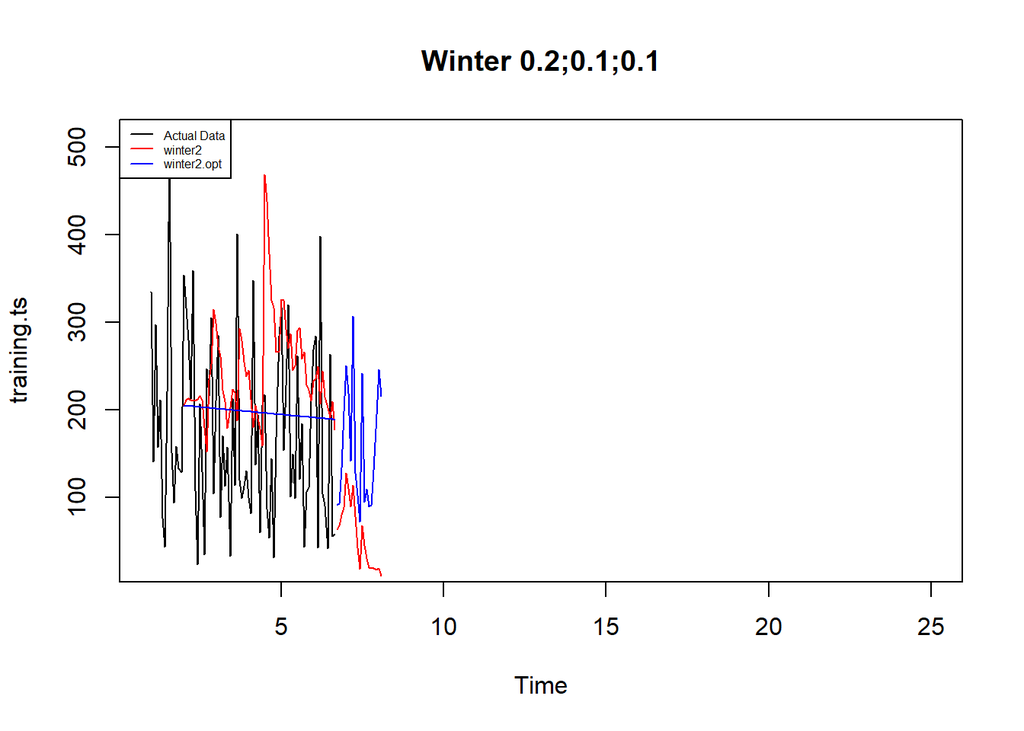

```r
#Plot time series
plot(training.ts,main="Winter 0.2;0.1;0.1",type="l",col="black",
     xlim=c(1,25),pch=12)
lines(xhat2,type="l",col="red")
lines(xhat2.opt,type="l",col="blue")
lines(forecast2,type="l",col="red")
lines(forecast2.opt,type="l",col="blue")
legend("topleft",c("Actual Data",expression(paste(winter2)),
                   expression(paste(winter2.opt))),cex=0.5,
       col=c("black","red","blue"),lty=1)
```

```r
#Akurasi data training
SSE2<-winter2$SSE
MSE2<-winter2$SSE/length(training.ts)
RMSE2<-sqrt(MSE2)
akurasi1 <- matrix(c(SSE2,MSE2,RMSE2))
row.names(akurasi1)<- c("SSE2", "MSE2", "RMSE2")
colnames(akurasi1) <- c("Akurasi lamda=0.2")
akurasi1
```

```
##       Akurasi lamda=0.2
## SSE2       1730103.7713
## MSE2         21626.2971
## RMSE2          147.0588
```

```r
SSE2.opt<-winter2.opt$SSE
MSE2.opt<-winter2.opt$SSE/length(training.ts)
RMSE2.opt<-sqrt(MSE2.opt)
akurasi1.opt <- matrix(c(SSE2.opt,MSE2.opt,RMSE2.opt))
row.names(akurasi1.opt)<- c("SSE2.opt", "MSE2.opt", "RMSE2.opt")
colnames(akurasi1.opt) <- c("Akurasi")
akurasi1.opt
```

```
##               Akurasi
## SSE2.opt  877502.2542
## MSE2.opt   10968.7782
## RMSE2.opt    104.7319
```

```r
akurasi2.train = data.frame(Model_Winter = c("Winter 1","winter2 optimal"),
                            Nilai_SSE=c(SSE2,SSE2.opt),
                            Nilai_MSE=c(MSE2,MSE2.opt),Nilai_RMSE=c(RMSE2,RMSE2.opt))
akurasi2.train
```

```
##      Model_Winter Nilai_SSE Nilai_MSE Nilai_RMSE
## 1        Winter 1 1730103.8  21626.30   147.0588
## 2 winter2 optimal  877502.3  10968.78   104.7319
```

```r
#Akurasi Data Testing
forecast2<-data.frame(forecast2)
testing.ts<-data.frame(testing.ts)
selisih2<-forecast2-testing.ts
SSEtesting2<-sum(selisih2^2)
MSEtesting2<-SSEtesting2/length(testing.ts)

forecast2.opt<-data.frame(forecast2.opt)
selisih2.opt<-forecast2.opt-testing.ts
SSEtesting2.opt<-sum(selisih2.opt^2)
MSEtesting2.opt<-SSEtesting2.opt/length(testing.ts)
```

```r
hasil <- data.frame(
  Model = c("Winter2", "Winter2.opt"),
  SSE   = c(SSEtesting2, SSEtesting2.opt),
  MSE   = c(MSEtesting2, MSEtesting2.opt)
)

print(hasil)
```

```
##         Model      SSE      MSE
## 1     Winter2 482768.4 482768.4
## 2 Winter2.opt 227461.4 227461.4
```

### Hasil dari peramalan dengan metode metode pemulusan tidak memberikan hasil yang sesuai harapan karena tidak ada yang memiliki nilai MAPE kurang dari 10% atau bisa dibilang akurasi peramalan data fmcg dengan metode metode pemulusan ini kurang baik dan mungkin harus menggunakan metode lain untuk mendapatkan peramalan dengan akurasi yang maksimal.